# IPL - Exploratory Data Analysis | Data Science | Python | AI

### By Santosh Dogra

#### Submitted to INSAID

1. Problem Statement
2. Data Loading and Description
3. Data Profiling
   - 3.1 Understanding the Dataset
   - 3.2 Pre Profiling
   - 3.3 Preprocessing
   - 3.4 Post Profiling
4. Seeking Answers (World Of #Ws)
   - 4.1 How many matches being played in each season?
   - 4.2 Which Team had won by maximum runs? (Overall & 2018)
   - 4.3 Which Team had won by maximum wickets? (Overall & 2018)
   - 4.4 Which Team had won by (closest margin) minimum runs?(Overall & 2018)
   - 4.5 Which Team had won by minimum wickets? (Overall & 2018)
   - 4.6 Which Season had most matches?
   - 4.7 Which City is most Popular in IPL?
   - 4.8 Which Stadium is getting Home Matches in IPL?
   - 4.9 Which Team is most successful in IPL
   - 4.10 How is Team Win Stats Standings YOY
   - 4.11 Highest Win % Market Share in IPL
   - 4.12 Top player of the match Winners
   - 4.13 Top player of the match Winners - 2018 & 2017
   - 4.14 Does Winning the Toss helps in Winning matches?
   - 4.15 Did Choosing to Bat first or Field First helped in Toss winning
   - 4.16 Match Winner is Toss Winner - Overall.
   - 4.17 Which Team Chose What - On Winning the Toss
   - 4.18 Analysing Impact of Toss Winning team Season By Season
   - 4.19 Who is Most Trusted Umpire in IPL
   - 4.20 Which Venue did Weather Affected Most
   - 4.21 Best Stadium to Chase and Win
   - 4.22 Best Team in Best Chasing Venue
   - 4.23 Best Stadium to Bat first and Win
   - 4.24 Best team in Best Defending Venue
   - 4.25 Which Team is Best in Defending
   - 4.26 Which Team is Best in Chasing
   - 4.27 Home Turf Advantage - Team wins in home city vs other cities
5. Conclusions

### 1. Problem Statement

In this we will analyse the IPL Data which was provided in Github link. The notebooks explores the basic use of **Pandas** and will cover the basic commands of **Exploratory Data Analysis(EDA)** which includes **cleaning**, **munging**, **combining**, **reshaping**, **slicing**, **dicing**, and **transforming data** for analysis purpose.

- **Exploratory Data Analysis**  
  We will Understand the data by EDA and derive simple models with Pandas as baseline. EDA ia a critical and first step in analyzing the data and we do this for below reasons :
  - Finding patterns in Data
  - Determining relationships in Data
  - Checking of assumptions
  - Preliminary selection of appropriate models

[figure not shown]

### 2. Data Loading and Description

- The dataset consists of the information about matches played in IPL season with data of wins, toss, umpire, venue etc.
- The dataset comprises of **696 observations of 18 columns**. Below is a table showing names of all the columns and their description.

| Column Name | Description |
| --- | --- |
| id | Unique Match Id |
| season | Year of Match |
| city | City where the match occurred |
| date | Date of match played |
| team1 | Team 1 Name |
| team2 | Team 2 Name |
| toss_winner | Team who won the toss |
| toss_decision | Decision of Toss Winner |
| result | Result of the match |
| dl_applied | Duckworth Luis method being applied or not |
| winner | Winner of the match |
| win_by_runs | Match won by defending |
| win_by_wickets | Match won by chasing |
| player_of_match | Player who won man of the match award |
| venue | Stadium Name |
| umpire1 | Umpire 1 Name |
| umpire2 | Umpire 2 Name |
| umpire3 | Umpire 3 Name |

### 2.1 IPL - The Prayer of Cricket Religion Country

The Indian Premier League (IPL) is a professional Twenty20 cricket league in India contested during April and May of every year by teams representing 8 Indian cities and some states.The league was founded by the Board of Control for Cricket in India (BCCI) in 2008, and is regarded as the brainchild of Lalit Modi, the founder and former commissioner of the league. IPL has an exclusive window in ICC Future Tours Programme.

The IPL is the most-attended cricket league in the world and in 2014 ranked sixth by average attendance among all sports leagues.In 2010, the IPL became the first sporting event in the world to be broadcast live on YouTube. The brand value of IPL in 2018 was US$6.3 billion, according to Duff & Phelps. According to BCCI, the 2015 IPL season contributed ₹11.5 billion (US$182 million) to the GDP of the Indian economy

There have been eleven seasons of the IPL tournament. The current IPL title holders are the Chennai Super Kings, who won the 2018 season.

### 2.2 How has IPL helped cricket in India & World?

The IPL has offered financial security to a wide range of cricketers. It has changed cricket’s commercial scenario so much that it has inspired the mushrooming of leagues across the cricket-playing world. Even in India, other sporting associations feel empowered to have their own leagues, leading to a win-win situation for athletes and fans.

*importing packages*

*We will Load Library for simplification of our life at beginning itself*

```python
import numpy as np # Implemennts milti-dimensional array and matrices
import pandas as pd # data manipulation, processing, CSV file I/O (e.g. pd.read_csv) and analysis
import pandas_profiling
import matplotlib.pyplot as plt #visualization, plotting library for python programming langauage and it's numberical mathematics extension NumPy
import seaborn as sns #modern visualization
import matplotlib as mat #visualization, provides a high level interface for drawing attractice and informative statistical graphics.
import bokeh #visualization
%matplotlib inline
sns.set()

from subprocess import check_output
```

We will define the theme and data size

```python
sns.set_style("darkgrid")
plt.rcParams['figure.figsize'] = (14, 8)
```

## 3. Data Profiling

### 3.1 Data Set Reading and Understanding Basic Structure & info**

To gain insights from data we must look into each aspect of it very carefully. We will start with observing few rows and columns of data both from the starting and from the end. We will import the data now and read the heading and couple of rows

```python
IPL = pd.read_csv("https://raw.githubusercontent.com/insaid2018/Term-1/master/Data/Projects/matches.csv") # Importing  dataset using pd.read_csv
IPL.head()
```

|  | id | season | city | date | team1 | team2 | toss_winner | toss_decision | result | dl_applied | winner | win_by_runs | win_by_wickets | player_of_match | venue | umpire1 | umpire2 | umpire3 |
| --- | --- | --- | --- | --- | --- | --- | --- | --- | --- | --- | --- | --- | --- | --- | --- | --- | --- | --- |
| 0 | 1 | 2017 | Hyderabad | 2017-04-05 | Sunrisers Hyderabad | Royal Challengers Bangalore | Royal Challengers Bangalore | field | normal | 0 | Sunrisers Hyderabad | 35 | 0 | Yuvraj Singh | Rajiv Gandhi International Stadium, Uppal | AY Dandekar | NJ Llong | NaN |
| 1 | 2 | 2017 | Pune | 2017-04-06 | Mumbai Indians | Rising Pune Supergiant | Rising Pune Supergiant | field | normal | 0 | Rising Pune Supergiant | 0 | 7 | SPD Smith | Maharashtra Cricket Association Stadium | A Nand Kishore | S Ravi | NaN |
| 2 | 3 | 2017 | Rajkot | 2017-04-07 | Gujarat Lions | Kolkata Knight Riders | Kolkata Knight Riders | field | normal | 0 | Kolkata Knight Riders | 0 | 10 | CA Lynn | Saurashtra Cricket Association Stadium | Nitin Menon | CK Nandan | NaN |
| 3 | 4 | 2017 | Indore | 2017-04-08 | Rising Pune Supergiant | Kings XI Punjab | Kings XI Punjab | field | normal | 0 | Kings XI Punjab | 0 | 6 | GJ Maxwell | Holkar Cricket Stadium | AK Chaudhary | C Shamshuddin | NaN |
| 4 | 5 | 2017 | Bangalore | 2017-04-08 | Royal Challengers Bangalore | Delhi Daredevils | Royal Challengers Bangalore | bat | normal | 0 | Royal Challengers Bangalore | 15 | 0 | KM Jadhav | M Chinnaswamy Stadium | NaN | NaN | NaN |

Checking getting basic *info*

```python
IPL.shape
IPL.info()
```

```
<class 'pandas.core.frame.DataFrame'>
RangeIndex: 696 entries, 0 to 695
Data columns (total 18 columns):
id                 696 non-null int64
season             696 non-null int64
city               689 non-null object
date               696 non-null object
team1              696 non-null object
team2              696 non-null object
toss_winner        696 non-null object
toss_decision      696 non-null object
result             696 non-null object
dl_applied         696 non-null int64
winner             693 non-null object
win_by_runs        696 non-null int64
win_by_wickets     696 non-null int64
player_of_match    693 non-null object
venue              696 non-null object
umpire1            695 non-null object
umpire2            695 non-null object
umpire3            60 non-null object
dtypes: int64(5), object(13)
memory usage: 98.0+ KB
```

Moving one level up, let’s perform a simple summary statistics using the method describe().

```python
IPL.describe()
```

|  | id | season | dl_applied | win_by_runs | win_by_wickets |
| --- | --- | --- | --- | --- | --- |
| count | 696.000000 | 696.000000 | 696.000000 | 696.000000 | 696.000000 |
| mean | 974.103448 | 2012.965517 | 0.027299 | 13.472701 | 3.349138 |
| std | 2143.239623 | 3.069266 | 0.163070 | 23.607994 | 3.411398 |
| min | 1.000000 | 2008.000000 | 0.000000 | 0.000000 | 0.000000 |
| 25% | 174.750000 | 2010.000000 | 0.000000 | 0.000000 | 0.000000 |
| 50% | 348.500000 | 2013.000000 | 0.000000 | 0.000000 | 3.000000 |
| 75% | 522.250000 | 2016.000000 | 0.000000 | 19.000000 | 6.000000 |
| max | 7953.000000 | 2018.000000 | 1.000000 | 146.000000 | 10.000000 |

```python
IPL.isnull().sum()
```

```
id                   0
season               0
city                 7
date                 0
team1                0
team2                0
toss_winner          0
toss_decision        0
result               0
dl_applied           0
winner               3
win_by_runs          0
win_by_wickets       0
player_of_match      3
venue                0
umpire1              1
umpire2              1
umpire3            636
dtype: int64
```

From the above output we can see that **city**, **winner**, **player_of_the_match** and **umpire3** columns contains **maximum null values**. We will see how to deal with them.

### 3.2 Pre Profiling

- By pandas profiling, an **interactive HTML report** gets generated which contins all the information about the columns of the dataset, like the **counts and type** of each *column*. Detailed information about each column, **coorelation between different columns** and a sample of dataset.
- It gives us **visual interpretation** of each column in the data.
- *Spread of the data* can be better understood by the distribution plot.
- *Grannular level* analysis of each column.

```python
profile = pandas_profiling.ProfileReport(IPL)
profile.to_file(outputfile="IPL_Profile.html")
```

**How many matches we’ve got in the dataset? ****bold text**

Its been noted that each ID counts the each variable, while each ID is nothing but matches. Total no of matches which will be analysed in data set is

```python
IPL['id'].count()
```

```
696
```

### How many seasons we’ve got in the dataset?

Lets seasons included in data sets. We will see how many unique season exist in dataset

```python
IPL['season'].unique()
```

```
array([2017, 2008, 2009, 2010, 2011, 2012, 2013, 2014, 2015, 2016, 2018],
      dtype=int64)
```

```python
len(IPL['season'].unique())
```

```
11
```

### Data Break Up

```python
IPL2008 = IPL[IPL['season'] == 2008]
IPL2009 = IPL[IPL['season'] == 2009]
IPL2010 = IPL[IPL['season'] == 2010]
IPL2011 = IPL[IPL['season'] == 2011]
IPL2012 = IPL[IPL['season'] == 2012]
IPL2013 = IPL[IPL['season'] == 2013]
IPL2014 = IPL[IPL['season'] == 2014]
IPL2015 = IPL[IPL['season'] == 2015]
IPL2016 = IPL[IPL['season'] == 2016]
IPL2017 = IPL[IPL['season'] == 2017]
IPL2018 = IPL[IPL['season'] == 2018]
```

### Heatmap

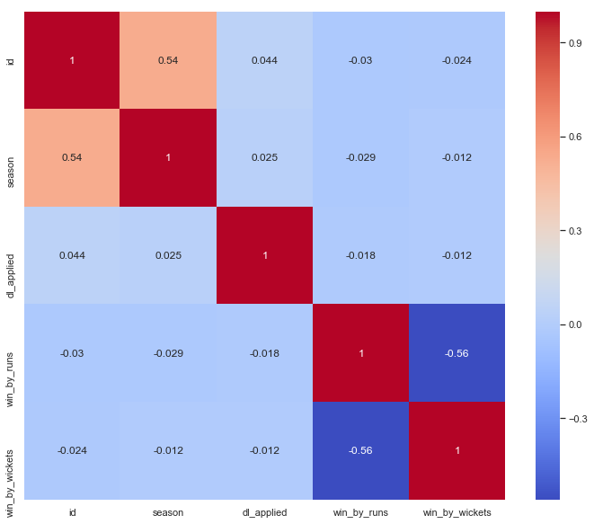

```python
f=IPL.corr()
plt.figure(figsize=(12,10))
sns.heatmap(f,annot=True,cmap='coolwarm')
plt.show()
```

There is negative correlataion between **win_by_runs** & **win_by_wickets**, and thats quite obvious, as one value will be 0 and they both can't co-exist together.

## 4. Seeking Answers (World Of #Ws)

### 4.1 How many matches being played in each season**

Lets check matches played each season

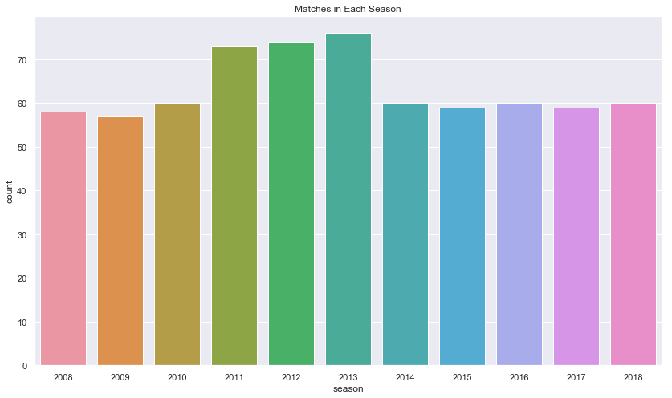

```python
plt.title('Matches in Each Season')
plt.xlabel('x')
plt.ylabel('y')
sns.countplot(x='season', data=IPL)
```

### 4.2 Which Team had won by maximum runs?**

#### Overall & 2018

Lets get the details of the match which has been won with maximum runs

```python
IPL.iloc[IPL['win_by_runs'].idxmax()]
```

```
id                               44
season                         2017
city                          Delhi
date                     2017-05-06
team1                Mumbai Indians
team2              Delhi Daredevils
toss_winner        Delhi Daredevils
toss_decision                 field
result                       normal
dl_applied                        0
winner               Mumbai Indians
win_by_runs                     146
win_by_wickets                    0
player_of_match         LMP Simmons
venue              Feroz Shah Kotla
umpire1                 Nitin Menon
umpire2                   CK Nandan
umpire3                         NaN
Name: 43, dtype: object
```

```python
IPL.iloc[IPL['win_by_runs'].idxmax()]['winner']
```

```
'Mumbai Indians'
```

```python
IPL2018.iloc[IPL['win_by_runs'].idxmax()]
```

```
id                                   7937
season                               2018
city                               Indore
date                             12/05/18
team1               Kolkata Knight Riders
team2                     Kings XI Punjab
toss_winner               Kings XI Punjab
toss_decision                       field
result                             normal
dl_applied                              0
winner              Kolkata Knight Riders
win_by_runs                            31
win_by_wickets                          0
player_of_match                 SP Narine
venue              Holkar Cricket Stadium
umpire1                          O Nandan
umpire2             Virender Kumar Sharma
umpire3                    Bruce Oxenford
Name: 679, dtype: object
```

*Overall Win By Runs = Mumbai Indians (146 Runs)*

### 4.3 Which Team had won by maximum wickets?

#### Overall & 2018

Similarly we can check which team has won by maximum wickets and details of that match

```python
IPL.iloc[IPL['win_by_wickets'].idxmax()]
```

```
id                                                      3
season                                               2017
city                                               Rajkot
date                                           2017-04-07
team1                                       Gujarat Lions
team2                               Kolkata Knight Riders
toss_winner                         Kolkata Knight Riders
toss_decision                                       field
result                                             normal
dl_applied                                              0
winner                              Kolkata Knight Riders
win_by_runs                                             0
win_by_wickets                                         10
player_of_match                                   CA Lynn
venue              Saurashtra Cricket Association Stadium
umpire1                                       Nitin Menon
umpire2                                         CK Nandan
umpire3                                               NaN
Name: 2, dtype: object
```

```python
IPL2018.iloc[IPL['win_by_wickets'].idxmax()]
```

```
id                                        7896
season                                    2018
city                                   Kolkata
date                                  08/04/18
team1              Royal Challengers Bangalore
team2                    Kolkata Knight Riders
toss_winner              Kolkata Knight Riders
toss_decision                            field
result                                  normal
dl_applied                                   0
winner                   Kolkata Knight Riders
win_by_runs                                  0
win_by_wickets                               4
player_of_match                      SP Narine
venue                             Eden Gardens
umpire1                          C Shamshuddin
umpire2                           A.D Deshmukh
umpire3                                 S Ravi
Name: 638, dtype: object
```

```python
IPL.iloc[IPL['win_by_wickets'].idxmax()]['winner']
```

```
'Kolkata Knight Riders'
```

### 4.4 Which Team had won by (closest margin) minimum runs?

#### Overall & 2018

```python
IPL.iloc[IPL[IPL['win_by_runs'].ge(1)].win_by_runs.idxmin()]
```

```
id                                                        59
season                                                  2017
city                                               Hyderabad
date                                              2017-05-21
team1                                         Mumbai Indians
team2                                 Rising Pune Supergiant
toss_winner                                   Mumbai Indians
toss_decision                                            bat
result                                                normal
dl_applied                                                 0
winner                                        Mumbai Indians
win_by_runs                                                1
win_by_wickets                                             0
player_of_match                                    KH Pandya
venue              Rajiv Gandhi International Stadium, Uppal
umpire1                                             NJ Llong
umpire2                                               S Ravi
umpire3                                                  NaN
Name: 58, dtype: object
```

```python
IPL2018.iloc[IPL[IPL['win_by_runs'].ge(1)].win_by_runs.idxmin()]
```

```
id                                  7952
season                              2018
city                             Kolkata
date                            25/05/18
team1                Sunrisers Hyderabad
team2              Kolkata Knight Riders
toss_winner        Kolkata Knight Riders
toss_decision                      field
result                            normal
dl_applied                             0
winner               Sunrisers Hyderabad
win_by_runs                           14
win_by_wickets                         0
player_of_match              Rashid Khan
venue                       Eden Gardens
umpire1                      Nitin Menon
umpire2                 Kumar Dharmasena
umpire3                   Anil Chaudhary
Name: 694, dtype: object
```

### 4.5 Which Team had won by minimum wickets?

#### Overall & 2018

```python
IPL.iloc[IPL[IPL['win_by_wickets'].ge(1)].win_by_wickets.idxmin()]
```

```
id                                   560
season                              2015
city                             Kolkata
date                          2015-05-09
team1                    Kings XI Punjab
team2              Kolkata Knight Riders
toss_winner              Kings XI Punjab
toss_decision                        bat
result                            normal
dl_applied                             0
winner             Kolkata Knight Riders
win_by_runs                            0
win_by_wickets                         1
player_of_match               AD Russell
venue                       Eden Gardens
umpire1                     AK Chaudhary
umpire2                  HDPK Dharmasena
umpire3                              NaN
Name: 559, dtype: object
```

```python
IPL2018.iloc[IPL['win_by_wickets'].idxmin()]
```

```
id                                7894
season                            2018
city                            Mumbai
date                          07/04/18
team1                   Mumbai Indians
team2              Chennai Super Kings
toss_winner        Chennai Super Kings
toss_decision                    field
result                          normal
dl_applied                           0
winner             Chennai Super Kings
win_by_runs                          0
win_by_wickets                       1
player_of_match               DJ Bravo
venue                 Wankhede Stadium
umpire1                 Chris Gaffaney
umpire2                A Nanda Kishore
umpire3                 Anil Chaudhary
Name: 636, dtype: object
```

**Kolkata Knight Riders and Chennai Super Kings have won by Narrowest margin in wickets**

### 4.6 Which Season had most matches?**

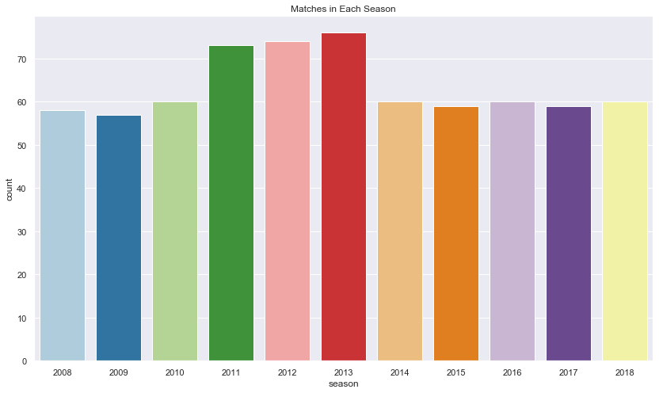

```python
plt.title('Matches in Each Season')
plt.xlabel('x')
plt.ylabel('y')

sns.countplot(x='season', data=IPL)
plt.show()
```

**Between 2011 & 2013 IPL had most matches. 2013 it had maximum**

### 4.7 Which City is most Popular in IPL

#### Overall & 2018

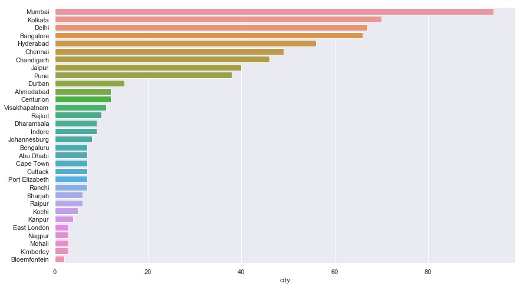

```python
data = IPL.city.value_counts()
sns.barplot(y = data.index, x = data, orient='h');
```

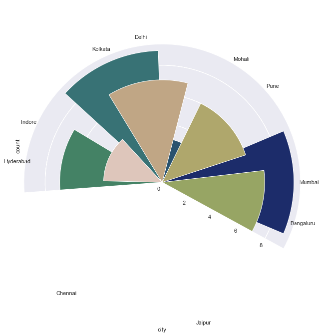

```python
fig=plt.figure(figsize=(10,12))
plt.subplot(polar=True)
sns.countplot(x='city',data=IPL2018, palette='gist_earth')
```

**Mumbai is clear distant Winner as far as popularity is concerned, Followed by Kolkata & Delhi. in 2018, Mumbai & Kolkata was popular city**

### 4.8 Which Stadium is getting Most Home Matches in IPL**

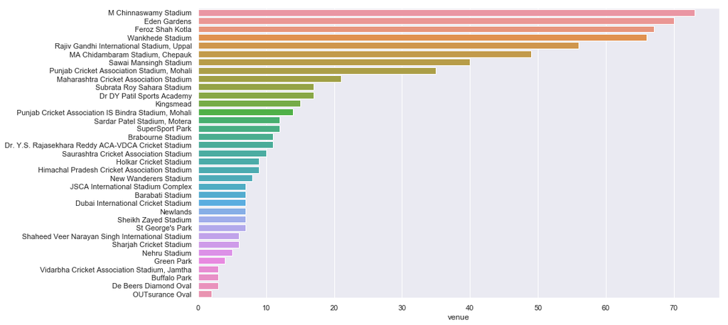

```python
data = IPL.venue.value_counts()
sns.barplot(y = data.index, x = data, orient='h');
```

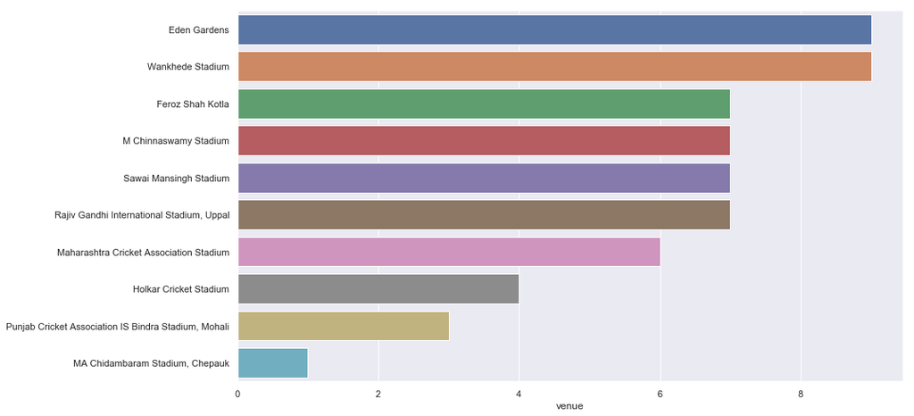

```python
data = IPL2018.venue.value_counts()
sns.barplot(y = data.index, x = data, orient='h');
```

### 4.9 Which Team is most successful in IPL**

Lets see, who has won the maximum matches in the dataset. We will count the winner and plot in graph

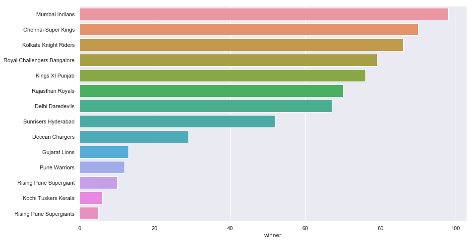

```python
data = IPL.winner.value_counts()
sns.barplot(y = data.index, x = data, orient='h');
```

**Mumbai indian comes distinctively as Top Successful Team Followed by Chennai Super Kings**

### 4.10 Team Win Stats Standings YOY

```python
pd.crosstab(IPL.winner,IPL.season)
```

| season winner | 2008 | 2009 | 2010 | 2011 | 2012 | 2013 | 2014 | 2015 | 2016 | 2017 | 2018 |
| --- | --- | --- | --- | --- | --- | --- | --- | --- | --- | --- | --- |
| Chennai Super Kings | 9 | 8 | 9 | 11 | 10 | 12 | 10 | 10 | 0 | 0 | 11 |
| Deccan Chargers | 2 | 9 | 8 | 6 | 4 | 0 | 0 | 0 | 0 | 0 | 0 |
| Delhi Daredevils | 7 | 10 | 7 | 4 | 11 | 3 | 2 | 5 | 7 | 6 | 5 |
| Gujarat Lions | 0 | 0 | 0 | 0 | 0 | 0 | 0 | 0 | 9 | 4 | 0 |
| Kings XI Punjab | 10 | 7 | 4 | 7 | 8 | 8 | 12 | 3 | 4 | 7 | 6 |
| Kochi Tuskers Kerala | 0 | 0 | 0 | 6 | 0 | 0 | 0 | 0 | 0 | 0 | 0 |
| Kolkata Knight Riders | 6 | 3 | 7 | 8 | 12 | 6 | 11 | 7 | 8 | 9 | 9 |
| Mumbai Indians | 7 | 5 | 11 | 10 | 10 | 13 | 7 | 10 | 7 | 12 | 6 |
| Pune Warriors | 0 | 0 | 0 | 4 | 4 | 4 | 0 | 0 | 0 | 0 | 0 |
| Rajasthan Royals | 13 | 6 | 6 | 6 | 7 | 11 | 7 | 7 | 0 | 0 | 7 |
| Rising Pune Supergiant | 0 | 0 | 0 | 0 | 0 | 0 | 0 | 0 | 0 | 10 | 0 |
| Rising Pune Supergiants | 0 | 0 | 0 | 0 | 0 | 0 | 0 | 0 | 5 | 0 | 0 |
| Royal Challengers Bangalore | 4 | 9 | 8 | 10 | 8 | 9 | 5 | 8 | 9 | 3 | 6 |
| Sunrisers Hyderabad | 0 | 0 | 0 | 0 | 0 | 10 | 6 | 7 | 11 | 8 | 10 |

### 4.11 Highest Win % Market Share in IPL

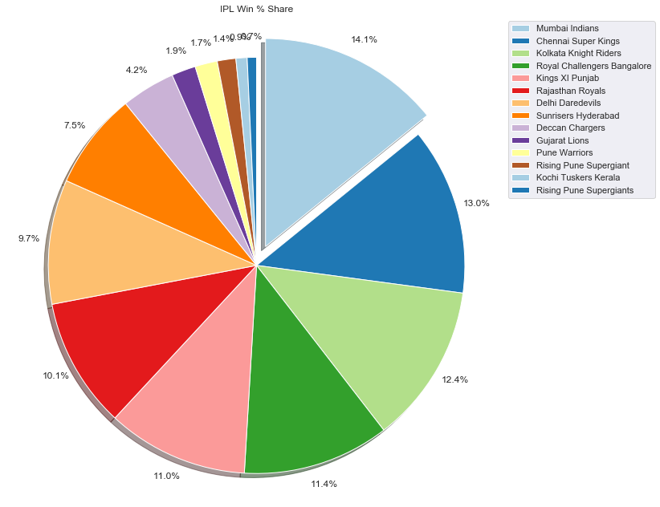

```python
import matplotlib.pyplot as plt
data = IPL.winner.value_counts()

plt.figure(figsize=(11,11)) #To Set Graph size

explode= (0.1,0,0,0,0,0,0,0,0,0,0,0,0,0)

plt.pie(data, explode=explode, counterclock=False, startangle=90, shadow='True', autopct='%.1f%%',pctdistance = 1.1)
plt.legend(data.index, loc="best", bbox_to_anchor = (1,1))
plt.axis('equal')
plt.title('IPL Win % Share')
plt.show()
```

**Mumbai Indian has highest Win% followed by Chennai Super Kings & Kolkata Knight Riders**

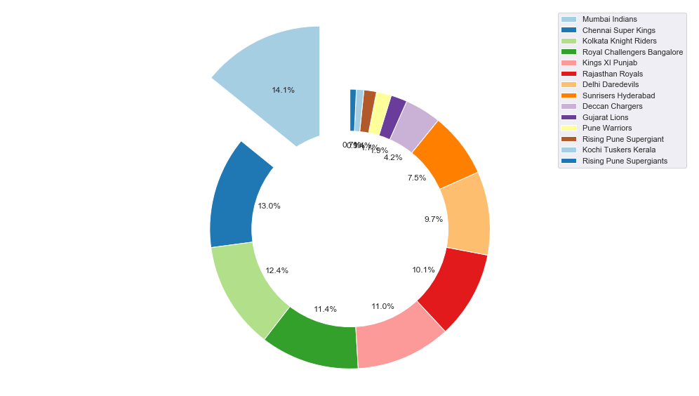

```python
fig1, ax1 = plt.subplots()
explode= (0.5,0,0,0,0,0,0,0,0,0,0,0,0,0)
ax1.pie(data, autopct='%1.1f%%', explode=explode, startangle=90)
#draw circle
centre_circle = plt.Circle((0,0),0.70,fc='white')
fig = plt.gcf()
fig.gca().add_artist(centre_circle)
# Equal aspect ratio ensures that pie is drawn as a circle
ax1.axis('equal')
plt.legend(data.index,loc='best')
plt.tight_layout()
plt.show()
```

### 4.12 Top player of the match Winners - Overall

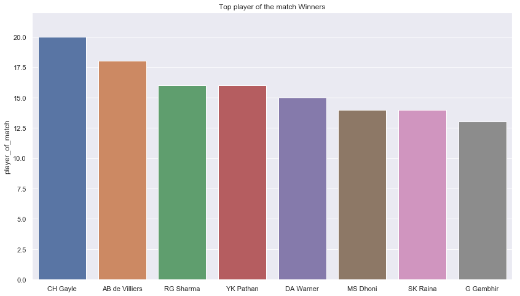

```python
top_players = IPL.player_of_match.value_counts()[:8]

fig, ax = plt.subplots()
ax.set_ylim([0,22])
ax.set_ylabel("Count")
ax.set_title("Top player of the match Winners")
#top_players.plot.bar()
sns.barplot(x = top_players.index, y = top_players, orient='v'); #palette="Blues");
plt.show()
```

### 4.13 Top player of the match Winners - 2018 & 2017

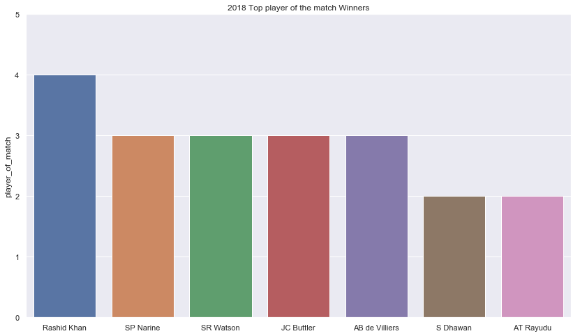

```python
top_players1 = IPL2018.player_of_match.value_counts()[:7]

fig, ax = plt.subplots()
ax.set_ylim([0,5])
ax.set_ylabel("Count")
ax.set_title("2018 Top player of the match Winners")
#top_players.plot.bar()
sns.barplot(x = top_players1.index, y = top_players1, orient='v'); #palette="Blues");
plt.show()
```

### 4.13 Top player of the match Winners - 2017

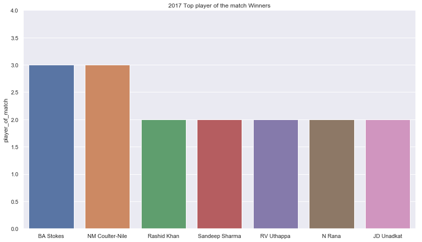

```python
top_players3 = IPL2017.player_of_match.value_counts()[:7]

fig, ax = plt.subplots()
ax.set_ylim([0,4])
ax.set_ylabel("Count")
ax.set_title("2017 Top player of the match Winners")
#top_players.plot.bar()
sns.barplot(x = top_players3.index, y = top_players3, orient='v'); #palette="Blues");
plt.show()
```

**Overall Chris Gayle, Rohit Sharma, AB Devillers are legends, but one Needs to watch out Rashid Khan in 2019. He is emerging Icons of IPL**

### 4.14 Does Winning the Toss helps in Winning matches?**

How much Toss winning Matters?

Lets analyse the data when Toss Winner is also the Match winner. We will analyse all the matches and try to figure out if there is any corelation

```python
ss = IPL['toss_winner'] == IPL['winner']
ss.groupby(ss).size()
```

```
False    339
True     357
dtype: int64
```

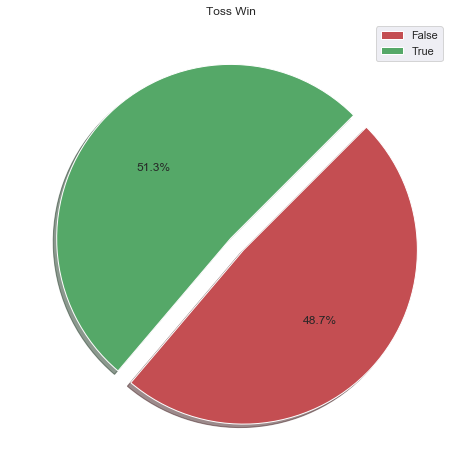

```python
import matplotlib.pyplot as plt

explode= (0.1,0)
colors=('r','g')
plt.pie(ss.groupby(ss).size(), explode= explode, colors=colors, counterclock=False, shadow ='True', startangle=45, autopct='%.1f%%')
plt.title('Toss Win')
plt.legend(ss, loc='best')
plt.show()
```

### 4.15 Did Choosing to Bat first or Field First helped in Toss winning**

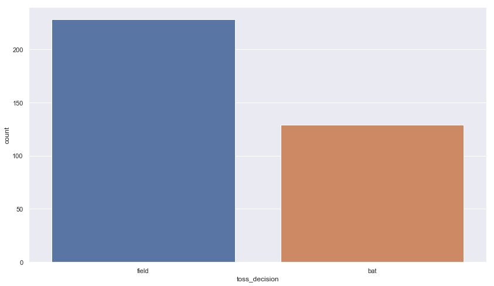

```python
sns.countplot(IPL.toss_decision[IPL.toss_winner == IPL.winner])
plt.show()
```

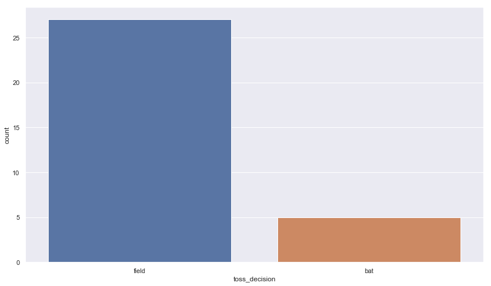

```python
sns.countplot(IPL2018.toss_decision[IPL.toss_winner == IPL.winner])
plt.show()
```

**Overall & in 2018, one most chose to field first.**

### Winner is Toss Winner too - Overall

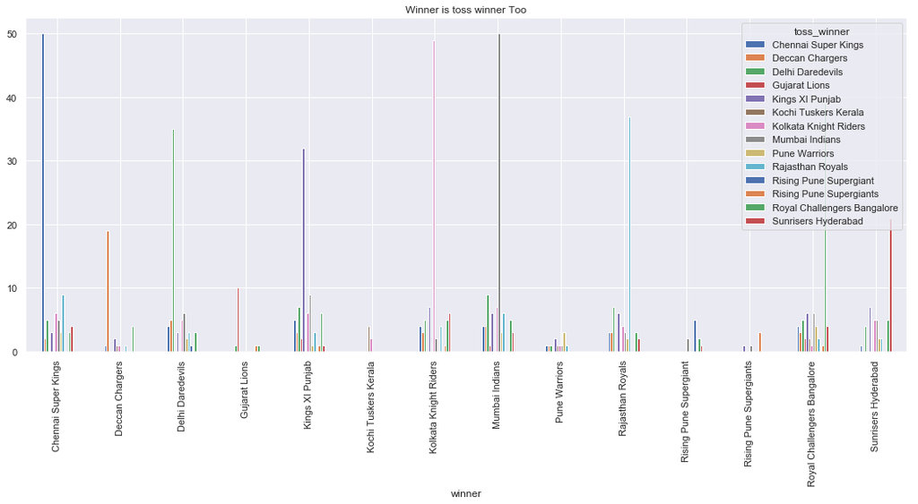

```python
pd.crosstab( IPL.winner , IPL.toss_winner).plot(kind = 'bar' , title = 'Winner is toss winner Too' , figsize=(18,7))
```

**The above bar chart indicates Winner has the advantage more when they win toss. We will analyse now season by season** **Mumbai Indian, CSK are the team who wins match, when they win toss**

### Which Team Chose What - On Winning the Toss

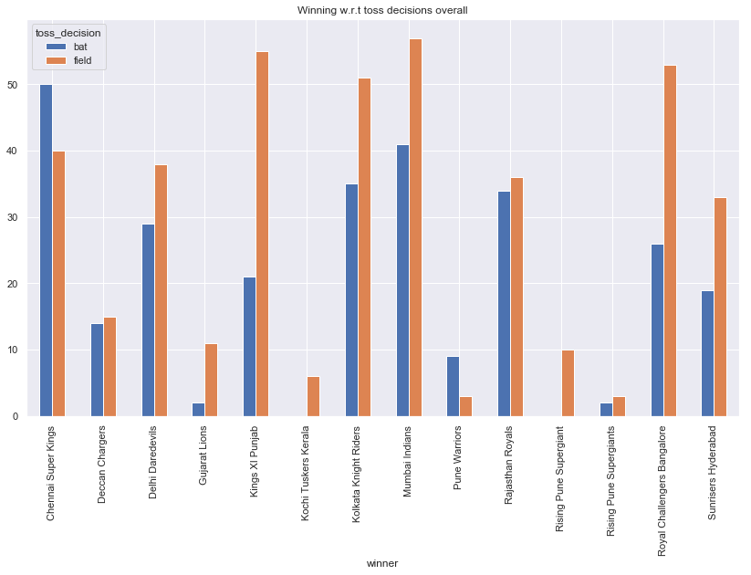

```python
pd.crosstab(IPL.winner,IPL.toss_decision).plot(kind='bar',title='Winning w.r.t toss decisions overall')
```

**The above data indicates that match Winner has mostly chosen to chase once won the toss. IPL provides edge to chasing.** **KKR, Mumbai Indian, RCB & KingsXIPunjab Prefers to field first**

### 4.18 Analysing Impact of Toss Winning team Season By Season

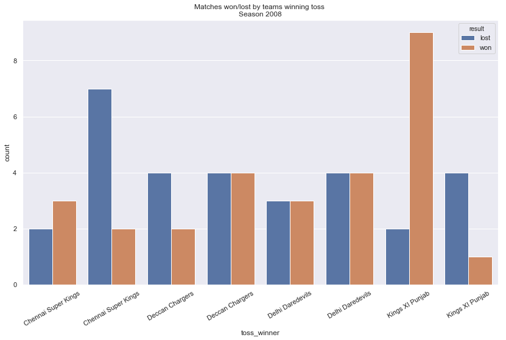

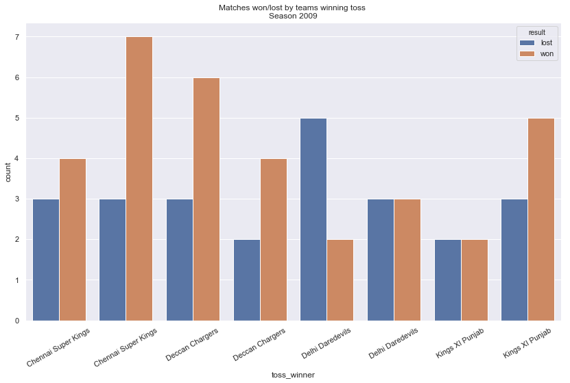

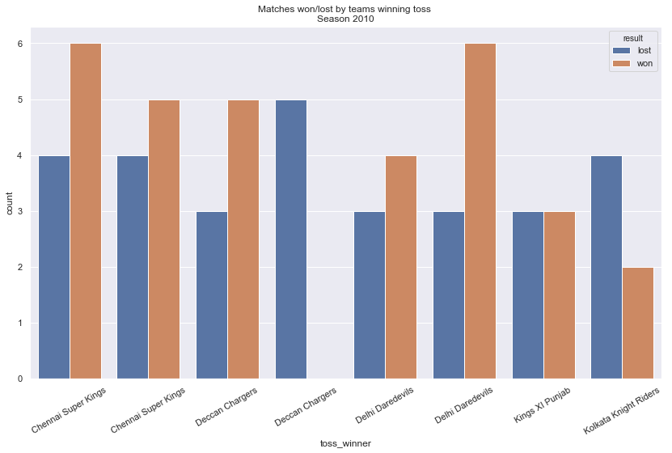

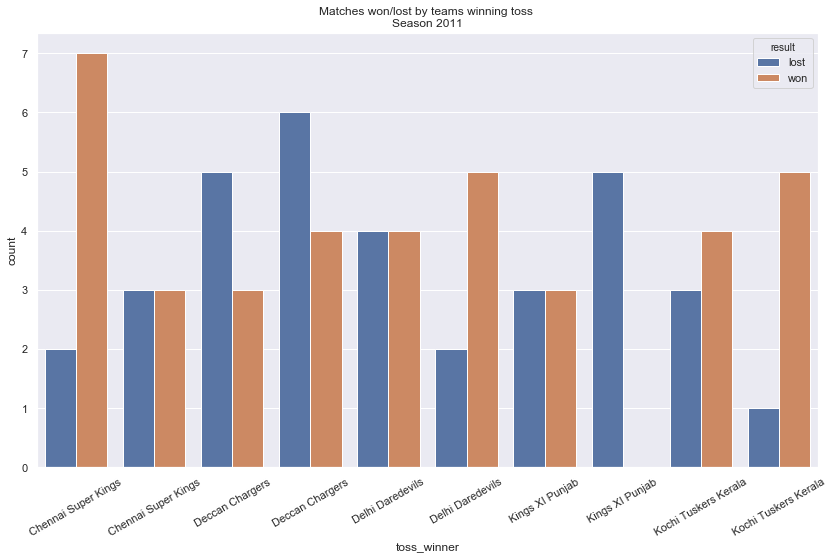

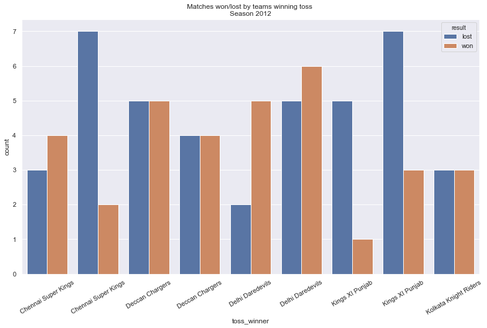

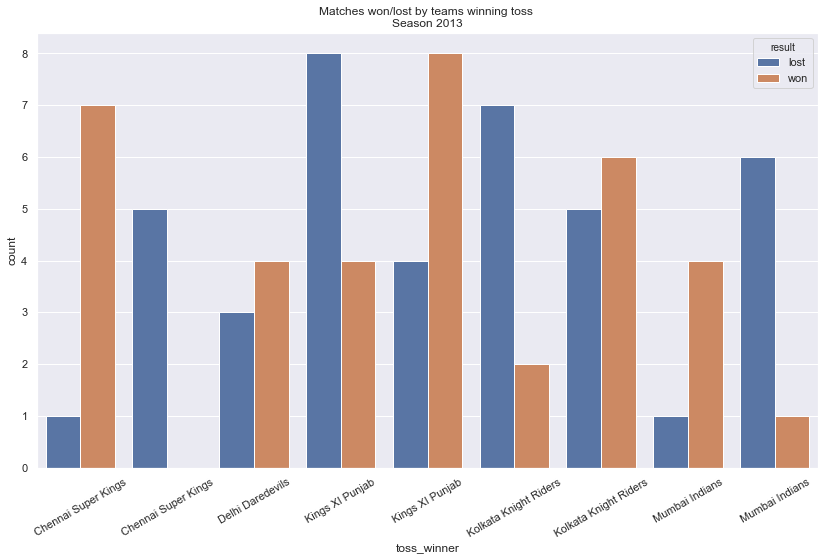

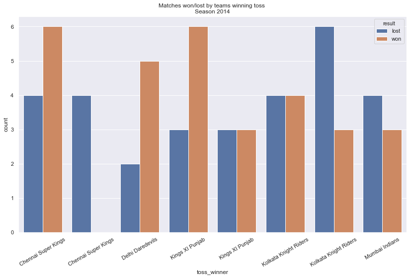

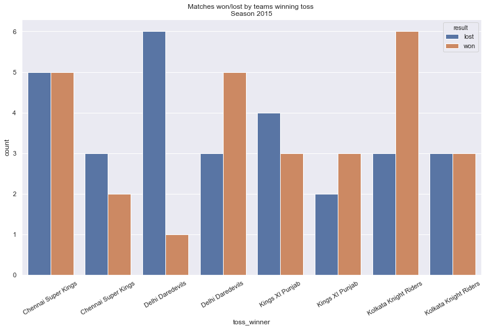

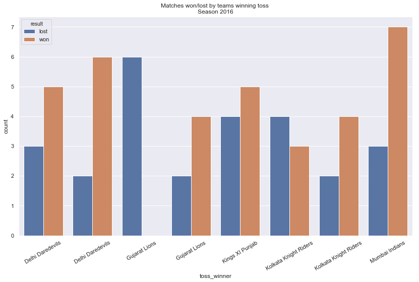

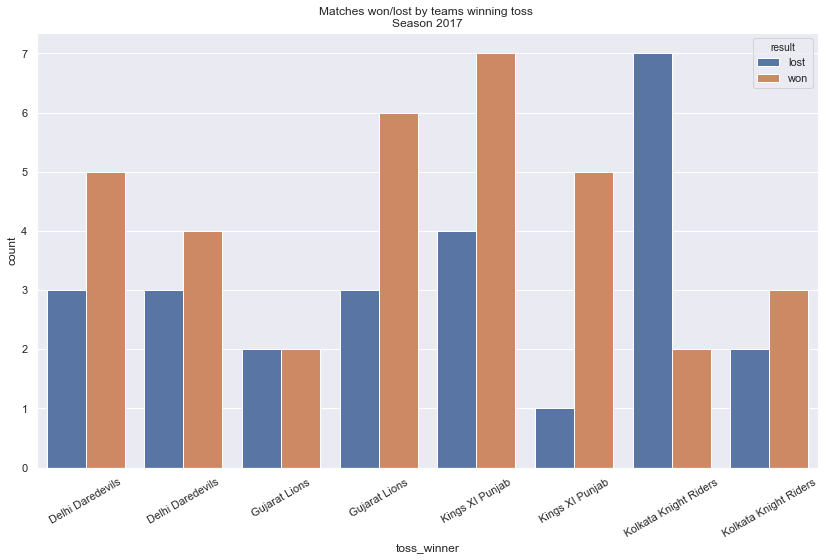

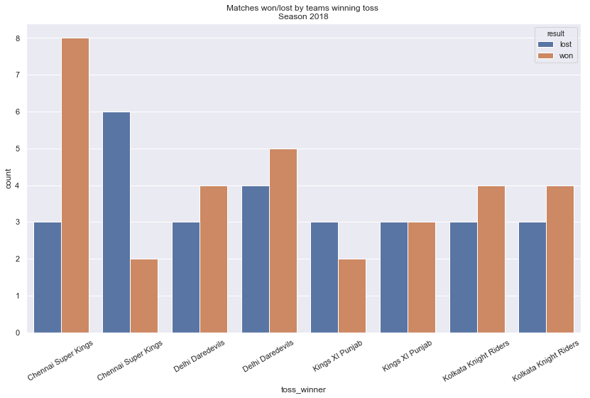

```python
toss = IPL.groupby(['season', 'toss_winner']).winner.value_counts().reset_index(name = 'count')
toss['result'] = np.where(toss.toss_winner == toss.winner, 'won', 'lost')
toss_result = toss.groupby(['season', 'toss_winner','result'])['count'].sum().reset_index()

for x in range(2008, 2019, 1):
    toss_result_x = toss_result[toss_result['season'] == x]
    plot = sns.barplot(x="toss_winner", y="count", hue="result", data=toss_result_x)
    plot.set_title('Matches won/lost by teams winning toss \nSeason ' +str(x))
    plot.set_xticklabels(toss_result_x['toss_winner'],rotation=30)
    plt.show()
    x+=1
```

**Overall it has been seen that Winning the Toss helps in Winning the match. 2018 reconfirms the Trend**